# Nicolai_ex04

Andrea Nicolai

29/4/2020

Exercise 1

where c ∈ [a, b].

```r
pdf1 <- function(x, a = 0, b = 1, c = 0.5) {
  temp <- ifelse (  (x < c) & ( x >= a ),
                   2*(x-a)/((b-a)*(c-a)),
                   ifelse (  (c <= x) & ( x <= b),
                            2*(b-x)/((b-a)*(b-c)),
                            0) )
  return(temp)
}

cdf1 <- function(x, a = 0, b = 1, c = 0.5) {
  temp <- ifelse ( (x >= a) & ( x < c),
                   ((x-a)^2)/((b-a)*(c-a)),
                    ifelse ( (c <= x) & ( b >= x),
                             1-((b-x)^2)/((b-a)*(b-c)),
                             ifelse ( x > b, 1, 0)))
  return(temp)
}
```

plot the function, given the interval (a, b)

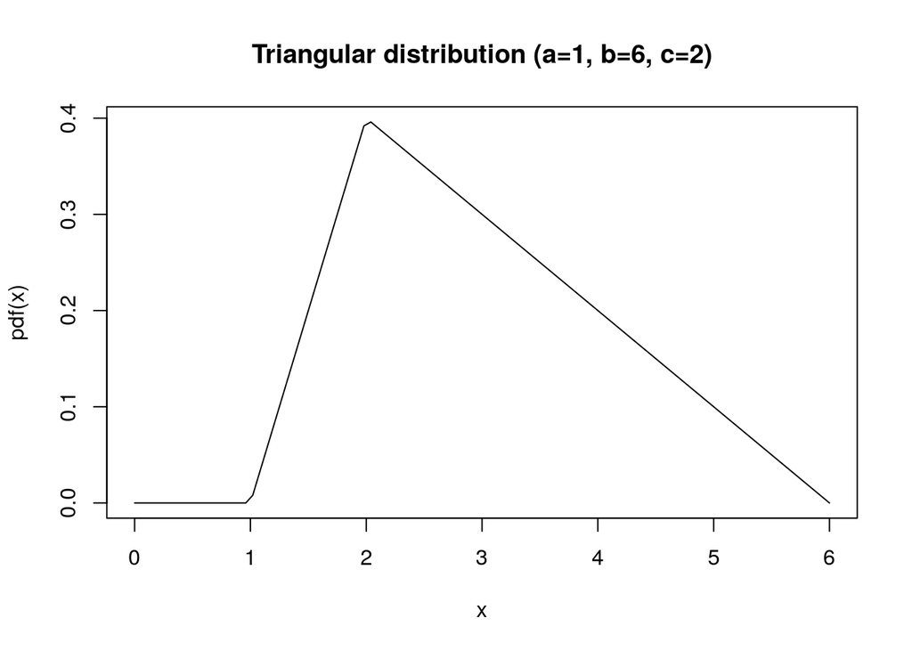

```r
curve(pdf1(x,1,6,2), from = 0, to = 6, ylab="pdf(x)", main = "Triangular distribution (a=1, b=6, c=2)" )
```

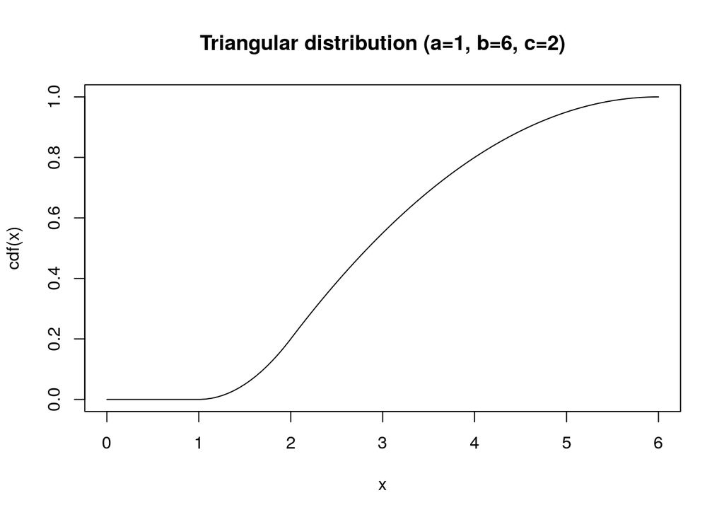

```r
curve(cdf1(x,1,6,2), from = 0, to = 6, ylab="cdf(x)", main = "Triangular distribution (a=1, b=6, c=2)" )
```

write an algorithm to generate random numbers from the triangular distribution

```r
random.1 <- function(n = 10000, a = 0, b = 1, c = 0.5) {
  func.max <- pdf1(c, a, b, c)
         u.1 <- runif(n, a , b)
         u.2 <- runif(n)
         y <- ifelse(u.2*func.max < pdf1(u.1, a, b, c), u.1, NA)
         y.clean <- y[!is.na(y)]
  return(y.clean)
}
```

generate 10^4 random number from the distribution, show them in an histogram and superimpose the analytical curve

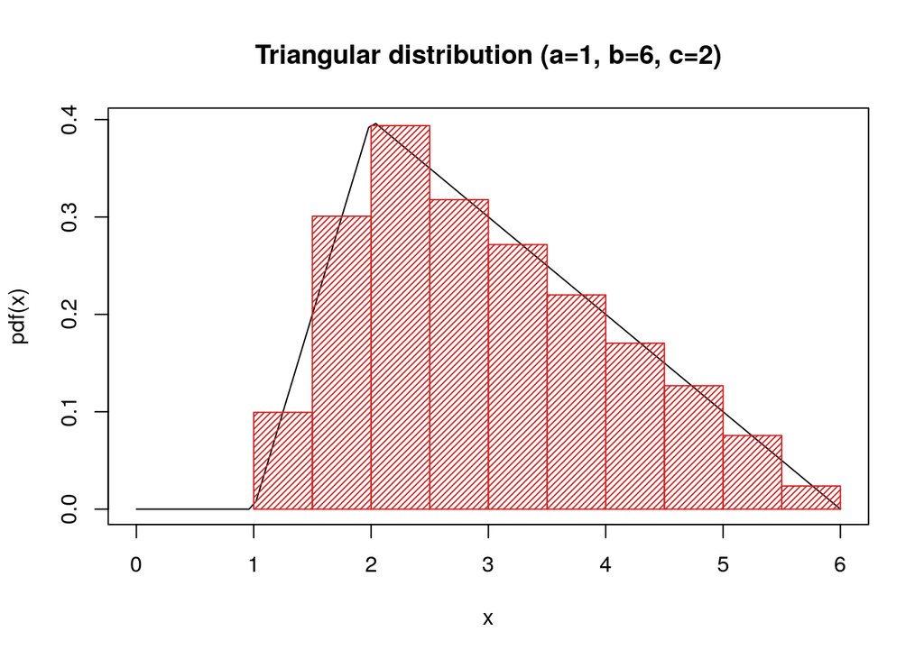

```r
x1 <- random.1(10^4,1,6,2)
while (length(x1) < 10^4){
  x1 <- c( x1, random.1(1,1,6,2))
}

curve(pdf1(x,1,6,2), from = 0, to = 6, ylab="pdf(x)", main = "Triangular distribution (a=1, b=6, c=2)", )
hist(x1, freq=F, col = 'firebrick3', density = 30 ,add=T)
```

Exercise 2

Given a discrete probability distribution, defined by the following probabilities: 0.05, 0.19, 0.14, 0.17, 0.02, 0.11, 0.06, 0.05, 0.04, 0.17

```r
x2 <- c(0.05, 0.19, 0.14, 0.17, 0.02, 0.11, 0.06, 0.05, 0.04, 0.17)

pdf2 <- function (x) {
 return(x2[floor(x)])
}

cdf2 <- function (x) {
  index <- floor(x)
  t1 <- x2[1:index]
  return( sum(t1) )
}
```

Plot the probability density function and the cumulative density function

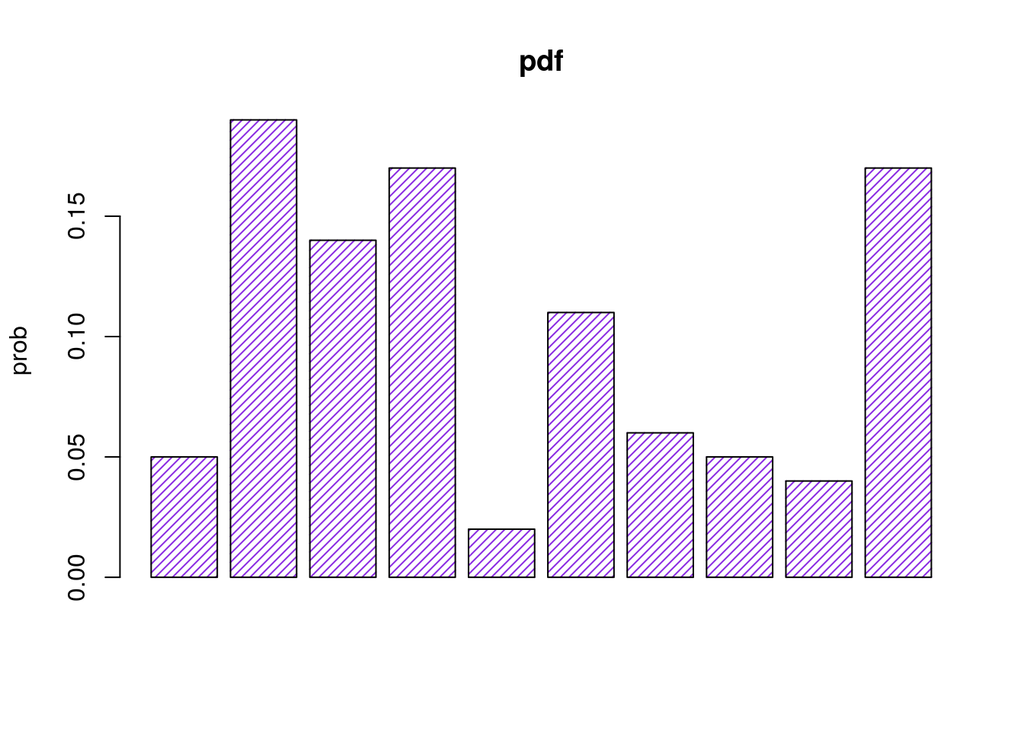

```r
barplot(x2, main="pdf", col = 'blueviolet', density = 24, ylab = 'prob')
```

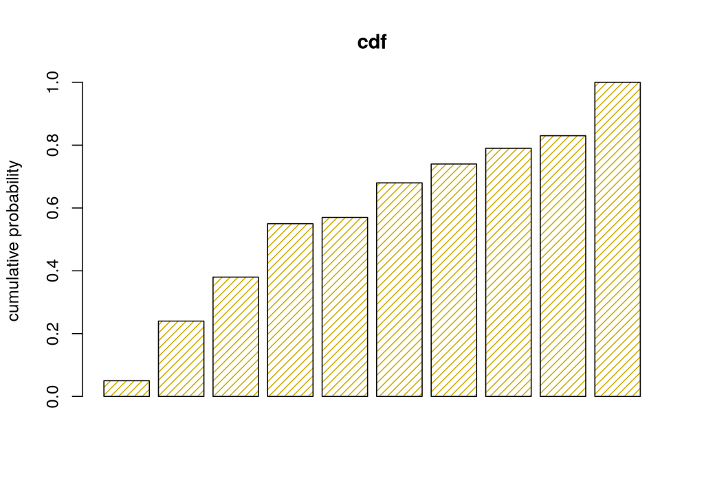

```r
y2 <- sapply(1:10, cdf2)
barplot(y2, main="cdf", col = 'gold3', density = 18, ylab ='cumulative probability' )
```

Write an algorithm to generate random numbers from the discrete probability distribution

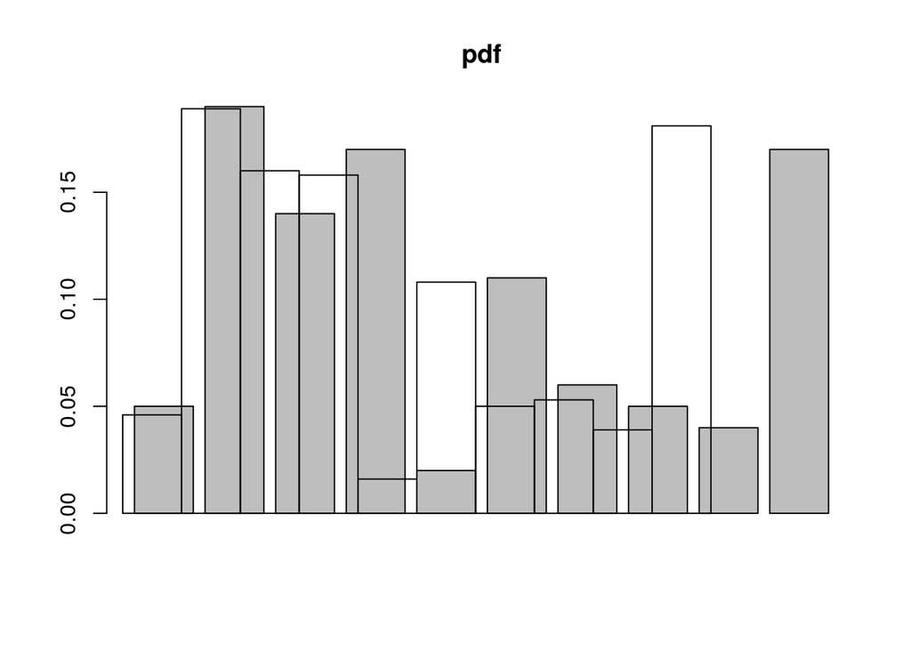

```r
random2 <- function (n) {
  vec <- 1:10
  x.2 <- c(NA)
  cumulative <- sapply(1:10, cdf2)

  while (length(x.2) < n+1) {
  u.2 <- runif(1)
  index <- length(cumulative[cumulative < u.2]) + 1
  ifelse ( index==1, y2 <- u.2/vec[index] , y2 <- vec[index -1 ] + (u.2 - cdf2(index -1 ))/pdf2(index))
  x.2 <- c(x.2,y2)}

  return(x.2[!is.na(x.2)])
}


sampled2 <- random2(1000)
barplot( x2 , main="pdf")
hist(sampled2, freq = FALSE, main = "sampled", add = T )
```

Exercise 3

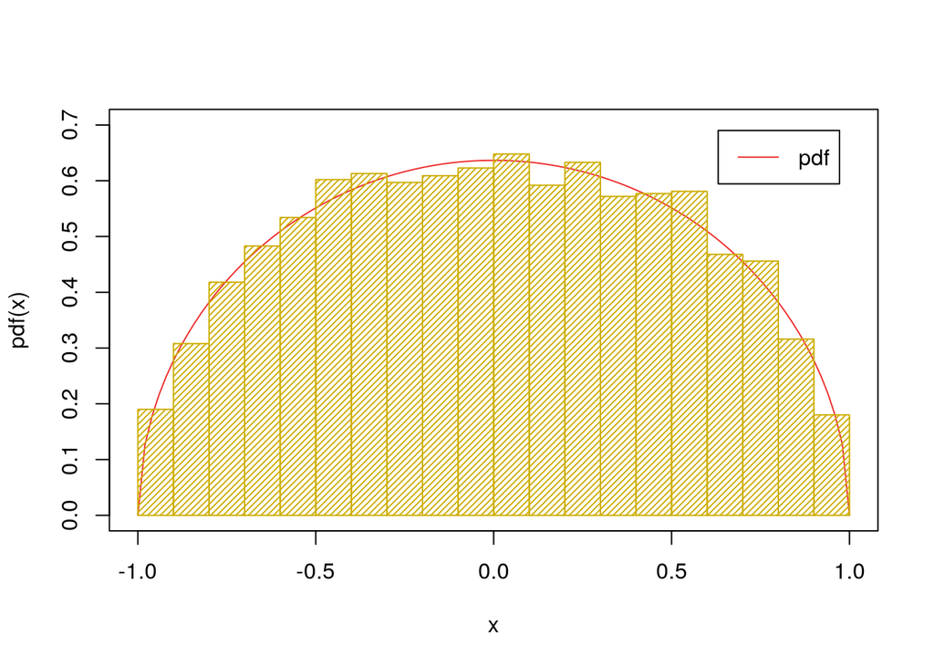

```r
#The distribution we are requested to implement is:
distrib3 <- function (x , R = 1) {
 tmp <- ifelse ( (x >= -R) & (x <= R), 2/(pi*R^2)*sqrt(R^2-x^2), NA)
 return(tmp)
}


#Acceptance rejection method algorithm
acc.rej <- function( n = 10^4 , R = 1 ) {
  u.1 <- runif(n, -R, R )
  u.2 <- runif(n)
  Max.f <- 2/(pi*R)
  y <- ifelse ( u.2*Max.f < distrib3(u.1,R) , u.1 , NA )
  y.clean <- y[!is.na(y)]
  return(y.clean)
}

#Generate 10^4 samples
x3 <- acc.rej(10^4)
while (length(x3) < 10^4){
  x3 <- c( x3, acc.rej(1))
}

#Make plots
curve(distrib3(x), from = -1, to = 1, ylab="pdf(x)", ylim = c(0, 0.7), col = 'firebrick2' )
hist(x3, freq=F, col = 'gold3', density = 30 ,add=T)
legend('topright', 'pdf', inset = 0.05, lty = 1, col = 'firebrick2')
```

if α = m is an integer, a random variable from gamma distribution Gamma(m, β) (also known as Erlang distribution) can be obtained by summing m independent exponential random variables X_j ∼ Exp(β):

$$Y = \beta \sum_{j=1}^n (- ln\ U_j) = -\beta\ ln \prod_{j=1}^n U_j$$
Write an algorithm to sample variables from an Erlang distribution Gamma(m, β):

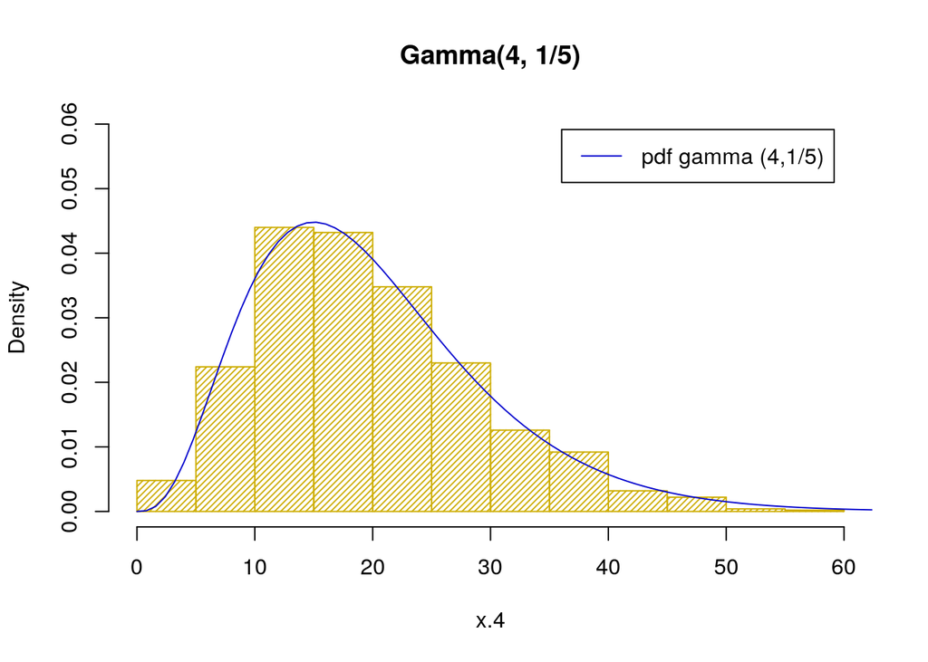

```r
#define the Gamma distribution
r.gamma <- function( alpha, beta,  n = 1000 ) {
  expon <-  replicate(n, 0)
  for (index in 1:alpha) {
    u.5 <- runif(n)
    expon <- (expon - beta*log(u.5))
  }
  return(expon)
}

x.4 <- r.gamma (4,5)
hist(x.4, freq = FALSE, ylim = c(0, 0.06),  col = 'gold3', density = 30, main = "Gamma(4, 1/5)")
curve(dgamma(x,4,1/5), add = T, from = 0, to = 80, ylab= "pdf", main= "Gamma(4, 1/5)", col = 'blue3')
legend('topright', 'pdf gamma (4,1/5)', inset = 0.05, lty = 1, col = 'blue3')
```

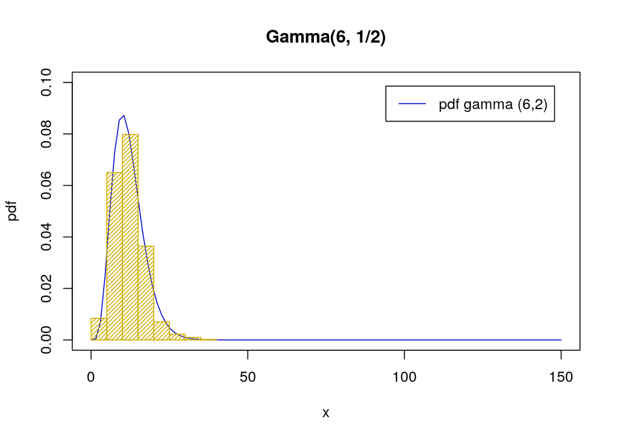

```r
y.4 <- r.gamma (6,2)
curve(dgamma(x,6,1/2), from = 0, to = 150, ylab= "pdf", main= "Gamma(6, 1/2)",ylim = c(0, 0.1), col = 'blue3')
hist(y.4, freq = FALSE, add = T, col = 'gold3', density = 30)
legend('topright', 'pdf gamma (6,2)', inset = 0.05, lty = 1, col = 'blue3')
```

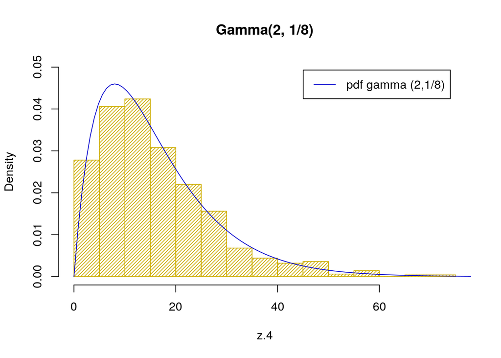

```r
z.4 <- r.gamma (2,8)
hist(z.4, freq = FALSE,  main= "Gamma(2, 1/8)", ylim = c(0, 0.05),col = 'gold3', density = 30 )
curve(dgamma(x,2,1/8), add = T, from = 0, to = 80, col = 'blue3')
legend('topright', 'pdf gamma (2,1/8)', inset = 0.05, lty = 1, col = 'blue3')
```

[figure not shown]

```r
#Gamma(1,1) it is indeed the exponential as we expected!
w.4 <- r.gamma (1,1)
hist(w.4, freq = FALSE, ylim = c(0, 1),  col = 'gold3', density = 30, main = "Gamma(1,1) and exp(rate = 1)")
curve(dgamma(x,1,1), add = T, from = 0, to = 8, ylab= "pdf", main= "Gamma(1, 1)", col = 'blue3', lty = 3, lw  = 2)
curve(dexp(x,1), add = T, from = 0, to = 8, col = 'red3', lty = 2)
legend('topright', c('pdf gamma (4,1/5)', 'exp(1)'), inset = 0.05, lty = c(3,2), col = c('blue3', 'red3'), lw = c(2,2))
```

Exercise 5 One of the first random number generator was proposed by von Neumann, the so-called middle square algorithm. write R code to implement this type of generator and, given a fixed digit number input, square it an remove the leading and trailing digits, in order to return a number with the same number of digits as the original number. Suggestion : after having squared the number, convert it to a list of characters and, after having removed the head and tail of the list, convert it back to a number

```r
# N = numbers to be generated
# first = input number

middle.square <- function (N, first) {

  #Check how many digits does the input number have
  digits <- length(unlist(strsplit(as.character(first),"")))

  #check whether the number has odd or even number of digits and set parameters accordingly
  if (digits%%2 == 0) {
    a <- digits/2 + 1
    b <- digits/2 + digits
  }
  if (digits%%2 == 1 ) {
    a <- digits/2 + 1/2
    b <- digits/2 + digits - 1/2
  }

  numbers <- c(NA)

  #generate N numbers to be squared and then trimmed
  for (i in 1:N) {
    ifelse (i == 1,
            temp <- first*first,
            temp <- numbers[i]^2 )

    temp <- unlist(strsplit(as.character(temp),""))
    temp <- temp[a:b]
    temp <- as.numeric(paste(temp,collapse = ""))
    numbers <- c(numbers, temp)
    }
  return(numbers[!is.na(numbers)])
}

middle.square(4,5772156649)
```

```
## [1] 7923805949 7007174077 4885453808 6589101017
```